# Estimating the current size of the 2026 DRC Bundibugyo virus outbreak

```julia
# Confirmed cases are scored over two groups of laboratory windows: the
# early confirmed vintages (no per-vintage analysed denominator, scored
# as counts against the modelled laboratory volume) and the observed
# windows (a Binomial of the observed analysed denominator). Both groups
# produce per-window replicate increments in `predict`, so concatenating
# them oldest-first gives the per-vintage cumulative confirmed-case
# trajectory, grounded on the observed cumulative confirmed at each window
# end-day. The 24-25 May analysis stall merges into 26 May, so the window
# grid is slightly coarser than the raw confirmed history.
_conf_windows = BVDOutbreakSize.confirmed_positivity_windows(
    obs.confirmed_history, obs.lab_history, obs.lab_daily_history);
# Oldest-first: early (no denominator) → observed (analysed Binomial) →
# late (post-28 May; trusted 24h-analysed days are Binomial windows, the
# rest unanchored windows scored against the modelled volume).
_conf_window_days = vcat(_conf_windows.early_days, _conf_windows.obs_days,
    _conf_windows.late_days);
function _confirmed_at(day)
    i = searchsortedlast(obs.confirmed_history.days, day)
    return i == 0 ? 0 : Int(obs.confirmed_history.counts[i])
end;
_conf_early = _vintage_replicates(
    pp_joint, @varname(early_increments.increments));
_conf_obs = collect(first(pp_joint[k]
for k in keys(pp_joint)
if occursin("confirmed_state.confirmed_positives.positives", string(k))));
_conf_late = _vintage_replicates(
    pp_joint, @varname(late_increments.increments));
confirmed_panel = (;
    id = :confirmed_cases,
    title = "Confirmed cases",
    dates = _vintage_dates(_conf_window_days),
    replicates = [vcat(collect(e), collect(p), collect(l))
                  for (e, p, l) in zip(vec(_conf_early), vec(_conf_obs), vec(_conf_late))],
    observed = [_confirmed_at(d) for d in _conf_window_days],
    colour = :goldenrod);

# Confirmed deaths are a per-vintage stream, scored as increments of the
# modelled confirmed-death trajectory up to the cut-off, so they get the
# same cumulative conditional check.
confirmed_deaths_panel = (;
    id = :confirmed_deaths,
    title = "Confirmed deaths",
    dates = _vintage_dates(obs.confirmed_deaths_history.days),
    replicates = _vintage_replicates(
        pp_joint, @varname(cdeath_increments.increments)),
    observed = obs.confirmed_deaths_history.counts, colour = :purple);

# Recovered among confirmed ("cumul guéris") is a cumulative per-vintage
# stream fitted through the increments of the modelled recovered trajectory
# (the confirmation-to-recovery convolution of the daily confirmed cases) up
# to the cut-off, so it gets the same cumulative conditional check.
recovered_panel = (;
    id = :recovered,
    title = "Recovered (confirmed)",
    dates = _vintage_dates(obs.recovered_history.days),
    replicates = _vintage_replicates(
        pp_joint, @varname(recovered_increments.increments)),
    observed = obs.recovered_history.counts, colour = :mediumseagreen);

# Tableau 6 treatment-centre daily flows (the new patient-movement data
# sources): admissions and the discharge reasons (in-care deaths, rule-outs,
# absconded). Per-day counts, so drawn with `cumulative = false` — each
# replicate is the modelled daily flow on a report day against the observed
# Tableau 6 count.
admissions_panel = (;
    id = :treatment_admissions,
    title = "Admissions/day",
    dates = _vintage_dates(obs.treatment_admissions_history.days),
    replicates = _vintage_replicates(
        pp_joint, @varname(admissions.obs)),
    observed = obs.treatment_admissions_history.counts,
    colour = :teal, cumulative = false);
incare_deaths_panel = (;
    id = :treatment_deaths,
    title = "In-care deaths/day",
    dates = _vintage_dates(obs.treatment_deaths_history.days),
    replicates = _vintage_replicates(
        pp_joint, @varname(incare_deaths.increments)),
    observed = obs.treatment_deaths_history.counts,
    colour = :darkred, cumulative = false);
ruleouts_panel = (;
    id = :treatment_ruleouts,
    title = "Rule-outs/day",
    dates = _vintage_dates(obs.treatment_ruleout_history.days),
    replicates = _vintage_replicates(
        pp_joint, @varname(ruleouts.increments)),
    observed = obs.treatment_ruleout_history.counts,
    colour = :goldenrod, cumulative = false);
absconded_panel = (;
    id = :treatment_absconded,
    title = "Absconded/day",
    dates = _vintage_dates(obs.treatment_absconded_history.days),
    replicates = _vintage_replicates(
        pp_joint, @varname(absconded.increments)),
    observed = obs.treatment_absconded_history.counts,
    colour = :slategray, cumulative = false);

# Tableau 6 occupancy split (`dont confirmes` / `dont suspects`): the two
# in-care prevalence sub-stocks. Per-day census counts, so drawn with
# `cumulative = false` — each replicate is the modelled confirmed-in-care or
# suspect-in-care bed count on a report day against the observed sub-stock.
# On these split days the total-occupancy panel is not scored, so the two
# sub-stock panels carry the window instead.
confirmed_incare_panel = (;
    id = :treatment_beds,
    title = "Confirmed in care",
    dates = _vintage_dates(obs.treatment_confirmed_incare_history.days),
    replicates = _vintage_replicates(
        pp_joint, @varname(confirmed_incare_obs.increments)),
    observed = obs.treatment_confirmed_incare_history.counts,
    colour = :darkgoldenrod, cumulative = false);
suspect_incare_panel = (;
    id = :suspect_beds,
    title = "Suspects in care",
    dates = _vintage_dates(obs.treatment_suspect_incare_history.days),
    replicates = _vintage_replicates(
        pp_joint, @varname(suspect_incare_obs.increments)),
    observed = obs.treatment_suspect_incare_history.counts,
    colour = :chocolate, cumulative = false);

# Symptom-onset reporting triangle: one cell per (onset day, report day)
# pair, several onset dates per snapshot, unlike every panel above (one
# value per report day). To fit the same per-vintage panel shape, sum
# the cells sharing a report day into one net correction per snapshot —
# "one panel showing each snapshot as of its own report date" — rather
# than a full onset-by-report grid (shown separately as the fitted-vs-
# digitised snapshot figure in the Results section above). Per-day net
# correction, not a running total, so `cumulative = false`.
_onset_ppc_report_days = sort(unique(obs.onset_curve_history.report_days))
_onset_ppc_groups = [findall(==(r), obs.onset_curve_history.report_days)
                     for r in _onset_ppc_report_days]
_onset_ppc_replicates_raw = _vintage_replicates(
    pp_joint, @varname(onset_report_state.increments))
onset_panel = (;
    id = :onset_reports,
    title = "Onset reports (net correction/snapshot)",
    dates = _vintage_dates(_onset_ppc_report_days),
    replicates = [[sum(collect(rep)[g]) for g in _onset_ppc_groups]
                  for rep in vec(_onset_ppc_replicates_raw)],
    observed = [sum(obs.onset_curve_history.increments[g])
                for g in _onset_ppc_groups],
    colour = :mediumpurple, cumulative = false);
```

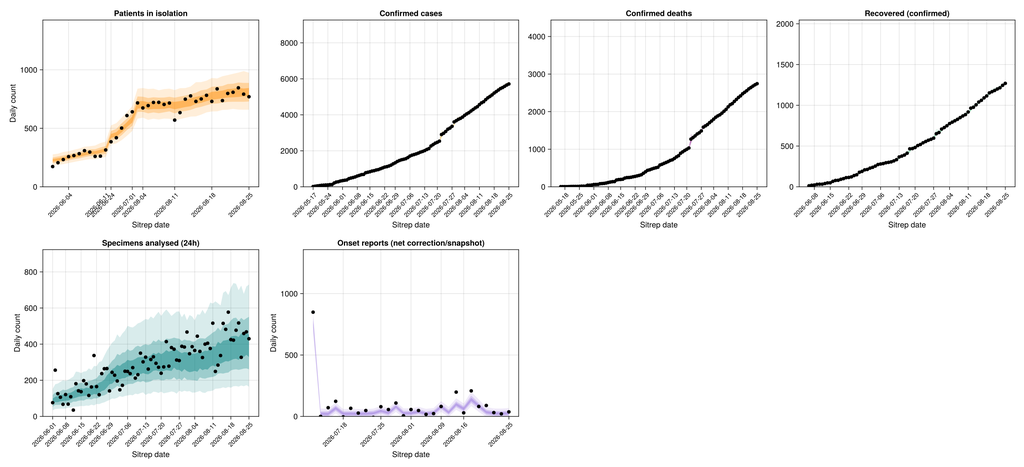

```julia
# Each panel runs to its own last vintage, so a stream that keeps
# reporting shows the full series the model is fitting rather than the
# window the streams that stopped earlier cover. The per-stream
# calibration table reads this ordered list too, so it stays whole and
# the two stream groups are filtered out of it.
vintage_panels = [
    reported_panel, suspected_daily_panel, isolation_panel, confirmed_panel,
    deaths_panel, suspected_daily_deaths_panel, confirmed_deaths_panel,
    recovered_panel, tests_analysed_panel, tests_analysed_daily_panel,
    admissions_panel, incare_deaths_panel, ruleouts_panel, absconded_panel,
    confirmed_incare_panel, suspect_incare_panel, onset_panel];
# The incidence view drops the treatment-centre flow and occupancy-split
# panels, whose per-day counts are already their own incidence.
vintage_incidence_panels = [
    reported_panel, suspected_daily_panel, isolation_panel, confirmed_panel,
    deaths_panel, suspected_daily_deaths_panel, confirmed_deaths_panel,
    recovered_panel, tests_analysed_panel, tests_analysed_daily_panel,
    onset_panel];
# Whether a panel's stream was still being reported at the cut-off, from
# the shared registry rule (last vintage within a week of the cut-off)
# rather than a per-page list of dates that goes stale.
_still_reporting(p) = stream_reporting(obs, p.id);
reporting_panels = filter(_still_reporting, vintage_panels);
stopped_panels = filter(!_still_reporting, vintage_panels);
reporting_incidence_panels = filter(
    _still_reporting, vintage_incidence_panels);
stopped_incidence_panels = filter(
    !_still_reporting, vintage_incidence_panels);
joint_vintage_ppc_fig = plot_vintage_conditional_ppc(reporting_panels);
```

##### Per-vintage incidence

This is the same check applied to per-vintage incidence: the count reported between consecutive situation reports, rather than the running cumulative. Plotting the increment lets a rise or a slowdown in each stream read directly off the height of each step, where the near-straight cumulative line would hide it. The replicates are the modelled per-vintage increments, shown as 30/60/90% credible ribbons with the observed increment overlaid.

**Per-vintage incidence posterior predictive plot**

julia

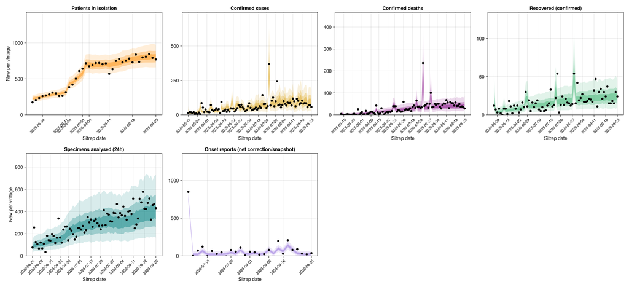

```julia
joint_vintage_incidence_fig = plot_vintage_incidence_ppc(
    reporting_incidence_panels);
```

#### Streams no longer reporting

These streams stopped reporting before the cut-off, so their panels end earlier than the ones above.

##### Cumulative

**Joint posterior predictive plot**

julia

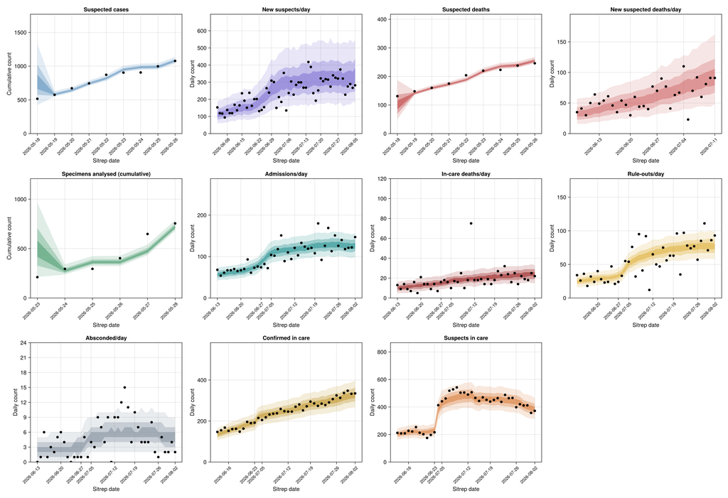

```julia
joint_vintage_ppc_stopped_fig = plot_vintage_conditional_ppc(stopped_panels);
```

##### Per-vintage incidence

**Per-vintage incidence posterior predictive plot**

julia

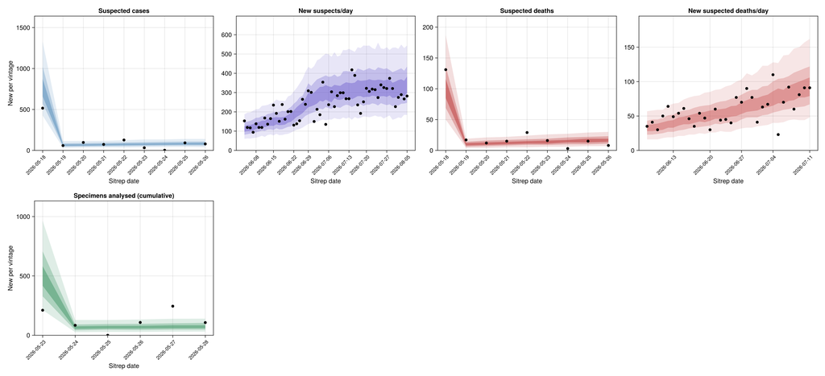

```julia
joint_vintage_incidence_stopped_fig = plot_vintage_incidence_ppc(
    stopped_incidence_panels);
```

#### Stream calibration

We score each stream's per-vintage conditional predictions against the observed counts. `bias` is the mean forecast bias over the vintages (negative under-predicted, positive over-predicted, zero when the observed counts sit at the predictive median). `50%/90% coverage` are the fractions of vintages whose observed count falls inside the central 50% and 90% predictive intervals; a well-calibrated stream keeps these near the nominal levels. Streams with a large bias or coverage far from nominal are the ones the joint fit reproduces less well.

julia

```julia
stream_calibration_table = stream_calibration(vintage_panels);
```

The calibration plot reads the table at a glance. The left panel marks each stream's empirical 50% and 90% coverage against dashed reference lines at the nominal levels. The right panel marks the mean forecast bias against a dashed line at zero.

**Per-stream calibration plot**

julia

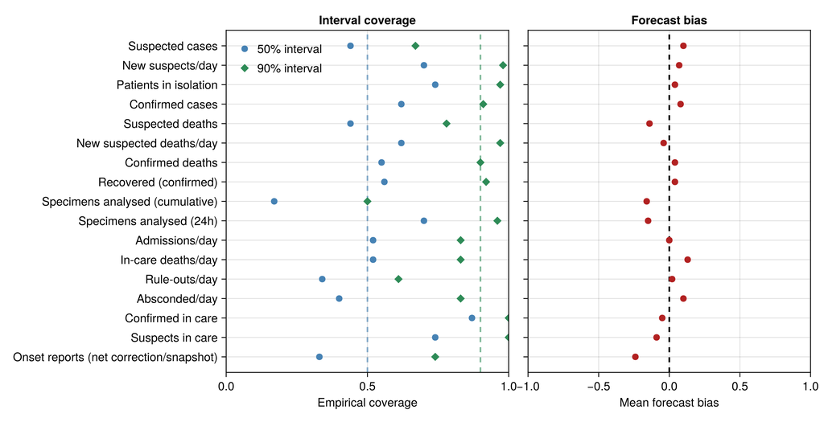

```julia
stream_calibration_fig = plot_stream_calibration(stream_calibration_table);
```

**Per-stream calibration table**

17×5 DataFrame

| Row | Stream String | Vintages Int64 | Bias Float64 | 50% coverage Float64 | 90% coverage Float64 |
| --- | --- | --- | --- | --- | --- |
| 1 | Suspected cases | 9 | 0.1 | 0.44 | 0.67 |
| 2 | New suspects/day | 57 | 0.07 | 0.7 | 0.98 |
| 3 | Patients in isolation | 38 | 0.04 | 0.74 | 0.97 |
| 4 | Confirmed cases | 94 | 0.08 | 0.62 | 0.91 |
| 5 | Suspected deaths | 9 | -0.14 | 0.44 | 0.78 |
| 6 | New suspected deaths/day | 32 | -0.04 | 0.62 | 0.97 |
| 7 | Confirmed deaths | 96 | 0.04 | 0.55 | 0.9 |
| 8 | Recovered (confirmed) | 75 | 0.04 | 0.56 | 0.92 |
| 9 | Specimens analysed (cumulative) | 6 | -0.16 | 0.17 | 0.5 |
| 10 | Specimens analysed (24h) | 77 | -0.15 | 0.7 | 0.96 |
| 11 | Admissions/day | 42 | 0.0 | 0.52 | 0.83 |
| 12 | In-care deaths/day | 42 | 0.13 | 0.52 | 0.83 |
| 13 | Rule-outs/day | 41 | 0.02 | 0.34 | 0.61 |
| 14 | Absconded/day | 42 | 0.1 | 0.4 | 0.83 |
| 15 | Confirmed in care | 38 | -0.05 | 0.87 | 1.0 |
| 16 | Suspects in care | 38 | -0.09 | 0.74 | 1.0 |
| 17 | Onset reports (net correction/snapshot) | 27 | -0.24 | 0.33 | 0.74 |

#### Exports

The Uganda export and export-death streams are dated per-day series, each import or death scored as a Poisson at its detection day. The scalar posterior predictive sums each replicate's per-day count vector across the dated days, giving the cumulative export and death total to compare with the observed count.

**Scalar posterior predictive plot**

julia

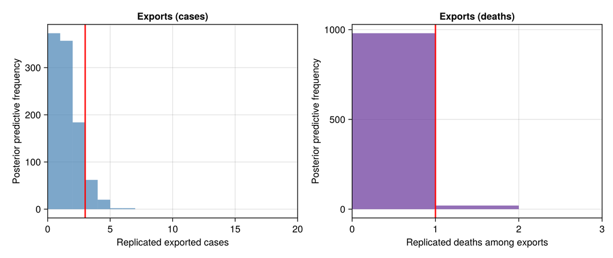

```julia
# The dated counts are nested under their submodel prefix as a single
# per-day count vector `<prefix>.counts`; look it up by its VarName with
# `Prefixed` (matching the key by its `<obs>.counts` tail) so the
# deterministic `expected_*_T` quantities cannot be picked up by a loose
# substring, then sum each replicate's per-day vector into the total.
function _dated_total(pp, vn)
    return [sum(v) for v in vec(Array(pp[_Prefixed(vn)]))]
end;

pp_exports = _dated_total(pp_joint, @varname(export_obs.counts));
pp_exports_deaths = _dated_total(
    pp_joint, @varname(death_obs.counts));

joint_ppc_fig = plot_posterior_predictive(
    pp_exports, nothing,
    obs.exported_cases, nothing;
    pp_exports_deaths = pp_exports_deaths,
    obs_exports_deaths = obs.exports_deaths);
```

### Symptom-onset reporting delay and ascertainment

**Reconstruct the onset-report hazard and calendar walk**

julia

```julia
# The report-date grid the calendar walk spans is a fixed function of the
# digitised triangle, not sampled, so it is recomputed once directly from
# `obs.onset_curve_history` rather than pulled from the chain (mirroring
# `onset_reporting_model`'s own `grid_start`/`grid_end` construction).
_onset_grid_start = isempty(obs.onset_curve_history.onset_days) ? 1 :
                    minimum(obs.onset_curve_history.onset_days)
_onset_grid_end = isempty(obs.onset_curve_history.report_days) ?
                  _onset_grid_start :
                  max(maximum(obs.onset_curve_history.report_days),
    _onset_grid_start)

# Every posterior draw's `logit_h0` (the baseline delay hazard) and `γ`
# (the report-date calendar walk), rebuilt from the non-centred
# innovations the chain stores. `reconstruct_onset_hazard` is the package
# function the onset forecast also uses, so the hazard plotted here and
# the one projected forward are the same object rather than two copies of
# the same reconstruction that could drift apart.
_onset_hazard = reconstruct_onset_hazard(chn_joint;
    grid_start = _onset_grid_start, grid_end = _onset_grid_end)

# A representative onset day (the median scored onset date), so the 7-day
# fraction below reflects a typical, not an edge, calendar day.
_onset_u_ref = isempty(obs.onset_curve_history.onset_days) ?
               _onset_grid_start :
               round(Int, quantile(obs.onset_curve_history.onset_days, 0.5))
# The delay profile is the normalised delay CDF, which reaches one by
# construction, so the 7-day fraction is read straight off it.
_onset_7d_fraction = [onset_report_G(6, _onset_hazard.logit_h0[i],
                          _onset_hazard.γ[i], _onset_u_ref,
                          _onset_grid_start)
                      for i in eachindex(_onset_hazard.logit_h0)]
filter!(isfinite, _onset_7d_fraction)

# Per-draw median ascertainment over the onset dates the ascertainment
# walk spans, then summarised across draws. Ascertainment is its own
# level rather than the delay hazard's asymptote (see the [symptom-onset
# reporting delay](@ref "Symptom-onset reporting delay") Methods section).
_onset_ascertainment_draws = [quantile(_onset_hazard.alpha[i], 0.5)
                              for i in eachindex(_onset_hazard.alpha)]

_onset_labels = merge(display_names,
    Dict(
        Symbol("onset_report_state.η0") => "onset-report hazard baseline (logit)",
        Symbol("onset_report_state.σ_h0") => "onset-report hazard pooling SD",
        Symbol("onset_report_state.σ_γ") => "onset-report calendar-walk step size",
        Symbol("onset_report_state.β") => "onset ascertainment offset (logit)",
        Symbol("onset_report_state.σ_a") => "onset ascertainment walk step size",
        Symbol("onset_report_state.σ_mult") => "onset-report scale slack"));
```

**Symptom-onset reporting-delay summary table**

julia

```julia
# Derived-quantity rows built with the same pre-prettify column schema
# `summary_table` uses, so they `vcat` cleanly onto its output.
onset_derived_raw = DataFrame(
    quantity = String[],
    lower_90 = Float64[], lower_60 = Float64[],
    lower_30 = Float64[], upper_30 = Float64[],
    upper_60 = Float64[], upper_90 = Float64[])
for (label, draws) in [
    ("share of eventual reports arriving within 7 days (median onset date)",
        _onset_7d_fraction),
    ("median modelled ascertainment", _onset_ascertainment_draws)]
    s = posterior_summary(draws)
    push!(onset_derived_raw,
        (label, round(s.lo90; digits = 3), round(s.lo60; digits = 3),
            round(s.lo30; digits = 3), round(s.hi30; digits = 3),
            round(s.hi60; digits = 3), round(s.hi90; digits = 3)))
end
onset_derived_table = BVDOutbreakSize._prettify(onset_derived_raw)

onset_summary = vcat(
    summary_table(chn_joint,
        [Symbol("onset_report_state.η0"), Symbol("onset_report_state.σ_h0"),
            Symbol("onset_report_state.σ_γ"),
            Symbol("onset_report_state.σ_mult")];
        digits = 3, labels = _onset_labels),
    onset_derived_table);
```

**Show symptom-onset reporting-delay summary table**

6×7 DataFrame

| Row | Quantity String | Lower 90% Float64 | Lower 60% Float64 | Lower 30% Float64 | Upper 30% Float64 | Upper 60% Float64 | Upper 90% Float64 |
| --- | --- | --- | --- | --- | --- | --- | --- |
| 1 | onset-report hazard baseline (logit) | -2.641 | -2.097 | -1.858 | -1.439 | -1.148 | -0.69 |
| 2 | onset-report hazard pooling SD | 0.753 | 0.944 | 1.07 | 1.354 | 1.534 | 1.85 |
| 3 | onset-report calendar-walk step size | 0.226 | 0.343 | 0.405 | 0.539 | 0.625 | 0.793 |
| 4 | onset-report scale slack | 1.0 | 1.001 | 1.002 | 1.004 | 1.006 | 1.01 |
| 5 | share of eventual reports arriving within 7 days (median onset date) | 0.283 | 0.341 | 0.368 | 0.418 | 0.446 | 0.496 |
| 6 | median modelled ascertainment | 0.192 | 0.232 | 0.263 | 0.314 | 0.35 | 0.408 |

**Symptom-onset reporting-delay pair plot (prior overlaid)**

julia

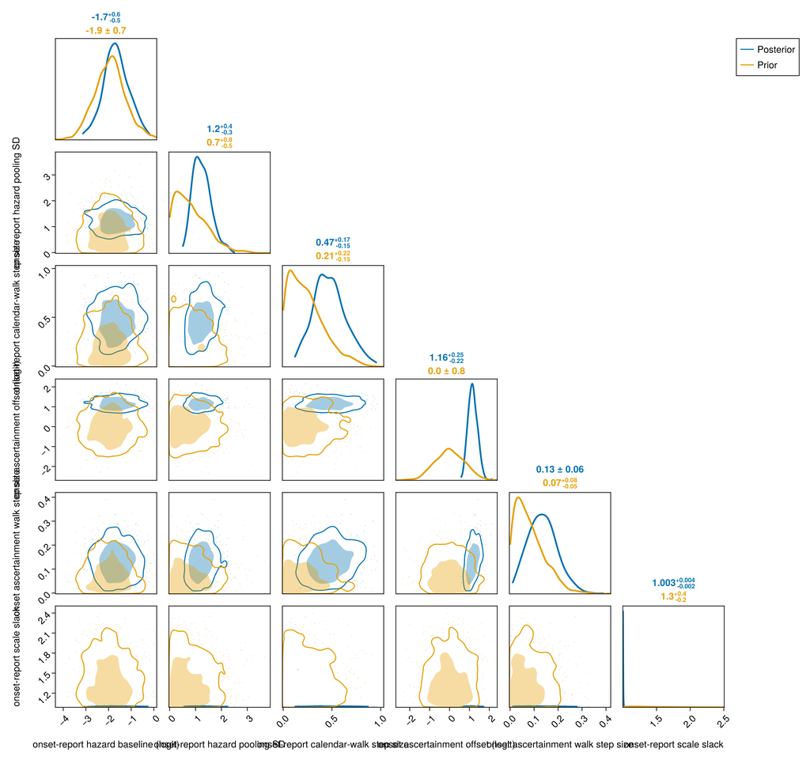

```julia
onset_pair_fig = plot_pair(chn_joint,
    [Symbol("onset_report_state.η0"), Symbol("onset_report_state.σ_h0"),
        Symbol("onset_report_state.σ_γ"),
        Symbol("onset_report_state.β"), Symbol("onset_report_state.σ_a"),
        Symbol("onset_report_state.σ_mult")];
    prior = prior_chn, labels = _onset_labels);
```

Each panel below is one digitised snapshot. Each point is one onset date's bar as that snapshot printed it, against the model's count for the same onset date and reporting delay. The dark band is the modelled count itself; the pale band adds the measurement error the likelihood gives a digitised bar. The points should fall inside the pale band, and do for 95% of cells, against 42% for the dark band alone. A recent onset date sits below its eventual value in its own snapshot's panel and catches up in a later panel. This is the right-truncation behaviour the model relies on (see the symptom-onset reporting delay Methods section).

**Fits to the digitised reporting-triangle snapshots**

julia

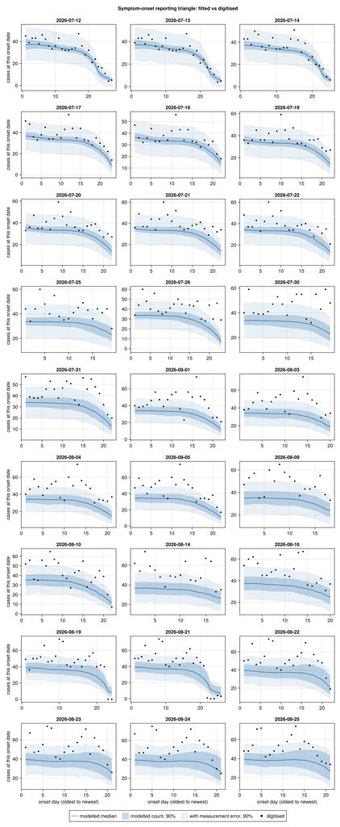

```julia
# The digitised, deduplicated, cut-off-filtered snapshot blocks
# `load_onset_curve` scores, kept here for their raw cumulative
# onset-date counts: the fitted stream only ever sees between-vintage
# increments, so the observed cumulative levels this figure plots are
# read back from the source blocks directly rather than reconstructed
# from the fitted increments.
_onset_path = joinpath(pkgdir(BVDOutbreakSize), "data",
    "onset_curve_scanned.csv")
_onset_snaps = filter(b -> b.report_date <= obs.cutoff,
    BVDOutbreakSize._dedup_onset_blocks(
        BVDOutbreakSize._read_onset_curve_blocks(_onset_path)))
# Keyed by report day rather than kept in order: a snapshot whose printed
# extent misses the scored window contributes no cells, so the panels and
# the snapshot blocks are not guaranteed to line up positionally.
_onset_snap_by_day = Dict(
    obs.n - value(obs.cutoff - b.report_date) => b for b in _onset_snaps)

# Cell indices grouped by their snapshot's report day, and the daily
# onsets series per posterior draw (the diff of the chain's stored
# `cumulative_onsets` trajectory; the model does not store the daily
# series itself, only its running sum).
_onset_cells_by_report = Dict{Int, Vector{Int}}()
for (i, r) in enumerate(obs.onset_curve_history.report_days)
    push!(get!(_onset_cells_by_report, r, Int[]), i)
end
_onset_report_grid_days = sort(collect(keys(_onset_cells_by_report)))
_onset_daily_draws = [vcat(v[1], diff(v))
                      for v in vec(collect(chn_joint[:cumulative_onsets]))]

# Ascertainment at onset day `u` for draw `i`, held flat at the ends of
# the fitted grid the same way the model extrapolates it.
function _onset_alpha(i::Integer, u::Integer)
    a = _onset_hazard.alpha[i]
    return a[clamp(u - _onset_grid_start + 1, 1, length(a))]
end

# Modelled count at onset day `u` as of report day `R`, per posterior
# draw: `onsets[u] * F(u, R - u)`, the same expected value
# `onset_report_expected_total` sums, evaluated at a single onset day.
function _onset_modelled_cumulative(u::Integer, R::Integer)
    return [_onset_daily_draws[i][u] *
            onset_report_F(R - u, _onset_hazard.logit_h0[i],
                _onset_hazard.γ[i], u, _onset_grid_start,
                _onset_alpha(i, u))
            for i in eachindex(_onset_daily_draws)]
end

# The same counts put through the stream's own observation model, so the
# band is a posterior predictive of a digitised bar rather than of the
# latent count behind it. A bar is one read off one scan with no previous
# level to difference against, which is `onset_report_scale`'s level case
# (`reads = 1`, `level_prev = 0`) — the case the first scored snapshot's
# own cells carry. Without this the band is the modelled count alone and
# covers 42% of the observed bars at a nominal 90%.
_onset_σ_mult = vec(collect(chn_joint[Symbol("onset_report_state.σ_mult")]))
_onset_ppc_rng = Random.MersenneTwister(20260729)
# Four replicates per draw rather than one: the band is a 90% interval of
# a heavy-tailed replicate, and at one per draw its edge is visibly ragged
# from Monte Carlo error alone.
function _onset_replicated(draws::AbstractVector)
    return [begin
                μ = draws[i]
                σ = _onset_σ_mult[i] * onset_report_scale(μ, μ, 0.0, 1)
                μ + σ * rand(_onset_ppc_rng, TDist(4.0))
            end
            for _ in 1:4 for i in eachindex(draws)]
end

onset_fit_fig = let
    ncol = 3
    nrow = cld(length(_onset_report_grid_days), ncol)
    fig = CairoMakie.Figure(; size = (330 * ncol, 260 * nrow + 60))
    for (k, R) in enumerate(_onset_report_grid_days)
        r, c = fldmod1(k, ncol)
        snap = _onset_snap_by_day[R]
        idx = sort(_onset_cells_by_report[R];
            by = i -> obs.onset_curve_history.onset_days[i])
        us = obs.onset_curve_history.onset_days[idx]
        observed = Float64[get(snap.onsets, grid_date(u), 0) for u in us]
        draws = [_onset_modelled_cumulative(u, R) for u in us]
        reps = [_onset_replicated(d) for d in draws]
        med = [quantile(d, 0.5) for d in draws]
        lo90 = [quantile(d, 0.05) for d in draws]
        hi90 = [quantile(d, 0.95) for d in draws]
        plo90 = [quantile(d, 0.05) for d in reps]
        phi90 = [quantile(d, 0.95) for d in reps]
        xs = Float64.(1:length(us))
        ax = CairoMakie.Axis(fig[r, c]; title = string(snap.report_date),
            xlabel = r == nrow ? "onset day (oldest to newest)" : "",
            ylabel = c == 1 ? "cases at this onset date" : "")
        CairoMakie.band!(ax, xs, plo90, phi90; color = (:steelblue, 0.12))
        CairoMakie.band!(ax, xs, lo90, hi90; color = (:steelblue, 0.30))
        CairoMakie.lines!(ax, xs, med; color = :steelblue, linewidth = 2,
            label = "modelled")
        CairoMakie.scatter!(ax, xs, observed; color = :black,
            markersize = 6, label = "digitised")
    end
    CairoMakie.Label(fig[0, 1:ncol],
        "Symptom-onset reporting triangle: fitted vs digitised";
        font = :bold, tellwidth = false)
    CairoMakie.Legend(fig[nrow + 1, 1:ncol],
        [CairoMakie.LineElement(color = :steelblue),
            CairoMakie.PolyElement(color = (:steelblue, 0.30)),
            CairoMakie.PolyElement(color = (:steelblue, 0.12)),
            CairoMakie.MarkerElement(color = :black, marker = :circle)],
        ["modelled median", "modelled count, 90%",
            "with measurement error, 90%", "digitised"];
        orientation = :horizontal, tellwidth = false)
    fig
end;
```

The posterior predictive below reads the same reporting triangle along the onset date instead of the report date. It compares the latest digitised bar for each onset date against the model's posterior predictive for that bar, and against the modelled onsets themselves. The gap between the two bands is the part of the epidemic the latest figure does not carry, whether because it is never ascertained or because it has not been reported yet.

**Reconstruct symptom onsets by date of onset**

julia

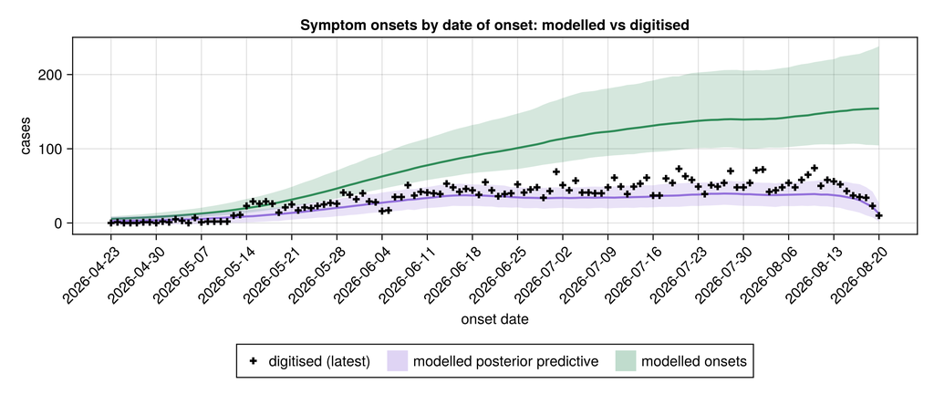

```julia
# Latest printed value for each onset date the digitised figures cover.
# Ordered by report date already, so the last block carrying a date gives
# the current reading. A date inside a block's own printed extent but with
# no row is a zero-height bar and does count; a date outside that extent is
# not covered by that figure at all and is skipped (the same rule the
# loader applies, see the [Data](@ref methods-data) section).
_onset_last_printed = Dict{Int, Float64}()
for snap in _onset_snaps
    lo, hi = extrema(keys(snap.onsets))
    for d in lo:Day(1):hi
        u = obs.n - value(obs.cutoff - d)
        (1 <= u <= obs.n) || continue
        _onset_last_printed[u] = Float64(get(snap.onsets, d, 0))
    end
end
_onset_by_date_days = sort(collect(keys(_onset_last_printed)))

# Modelled onsets on each of those days, and the count the latest figure
# should print for them: the same onsets times the cumulative reported
# proportion at that figure's own delay, `_onset_grid_end - u`, so the
# band is a predictive for the bar actually plotted rather than for the
# eventual total. `onset_report_F` holds the calendar walk flat past its
# fitted support, which the most recent onset dates run into.
_onset_by_date_onsets = [[_onset_daily_draws[i][u]
                          for i in eachindex(_onset_daily_draws)]
                         for u in _onset_by_date_days]
_onset_by_date_printed = [[_onset_daily_draws[i][u] *
                           onset_report_F(_onset_grid_end - u,
                               _onset_hazard.logit_h0[i], _onset_hazard.γ[i],
                               u, _onset_grid_start, _onset_alpha(i, u))
                           for i in eachindex(_onset_daily_draws)]
                          for u in _onset_by_date_days]
# That count put through the same measurement error a single digitised
# bar carries (`onset_report_scale`'s level case, as above the snapshot
# grid), replicated four times per draw for the same reason.
_onset_by_date_reps = [_onset_replicated(d) for d in _onset_by_date_printed]

onset_ppc_by_date_fig = let
    fig = CairoMakie.Figure(; size = (900, 380))
    ax = CairoMakie.Axis(fig[1, 1];
        title = "Symptom onsets by date of onset: modelled vs digitised",
        xlabel = "onset date", ylabel = "cases")
    xs = Float64.(_onset_by_date_days)
    q(ds, p) = [quantile(d, p) for d in ds]
    CairoMakie.band!(ax, xs, q(_onset_by_date_onsets, 0.05),
        q(_onset_by_date_onsets, 0.95); color = (:seagreen, 0.20))
    CairoMakie.lines!(ax, xs, q(_onset_by_date_onsets, 0.5);
        color = :seagreen, linewidth = 2)
    CairoMakie.band!(ax, xs, q(_onset_by_date_reps, 0.05),
        q(_onset_by_date_reps, 0.95); color = (:mediumpurple, 0.20))
    CairoMakie.lines!(ax, xs, q(_onset_by_date_reps, 0.5);
        color = :mediumpurple, linewidth = 2)
    CairoMakie.scatter!(ax, xs,
        [_onset_last_printed[u] for u in _onset_by_date_days];
        color = :black, marker = :cross, markersize = 9)
    # Calendar labels on a grid-day axis, at weekly ticks so they do not
    # collide at this width.
    _ticks = _onset_by_date_days[1:7:end]
    ax.xticks = (Float64.(_ticks), string.(grid_date.(_ticks)))
    ax.xticklabelrotation = pi / 4
    CairoMakie.Legend(fig[2, 1],
        [
            CairoMakie.MarkerElement(color = :black, marker = :cross),
            CairoMakie.PolyElement(color = (:mediumpurple, 0.30)),
            CairoMakie.PolyElement(color = (:seagreen, 0.30))],
        ["digitised (latest)", "modelled posterior predictive",
            "modelled onsets"];
        orientation = :horizontal, tellwidth = false, tellheight = true)
    fig
end;
```

### Posterior correlations and stream totals

**Posterior correlation heatmap**

julia

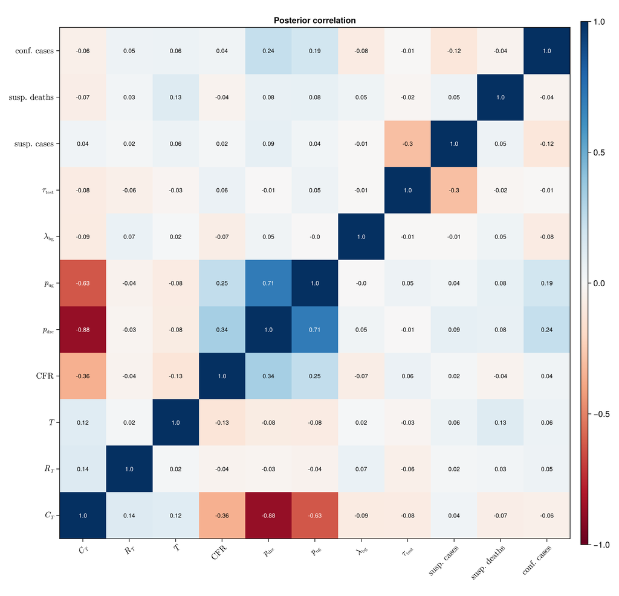

```julia
correlation_fig = plot_correlation_heatmap(chn_joint,
    [:C_T, :R_T, :T, :CFR, :p_drc, :p_uganda, :lambda_bg, :tau_test,
        :expected_reports_T, :expected_deaths_T, :expected_confirmed_T];
    labels = Dict(:C_T => raw"C_T", :R_T => raw"R_T", :T => raw"T",
        :CFR => raw"\mathrm{CFR}", :p_drc => raw"p_\mathrm{drc}",
        :p_uganda => raw"p_\mathrm{ug}", :lambda_bg => raw"\lambda_\mathrm{bg}",
        :tau_test => raw"\tau_\mathrm{test}",
        :expected_reports_T => raw"\mathrm{susp.\ cases}",
        :expected_deaths_T => raw"\mathrm{susp.\ deaths}",
        :expected_confirmed_T => raw"\mathrm{conf.\ cases}"));
```

The stream-total plot takes each posterior draw, sums every stream over its own reporting dates, and marks the observed total with a crosshair. The diagonal panels are the predictive spread of each total against the observed value. The off-diagonal panels show whether the totals move together from draw to draw.

**Stream totals against observed**

julia

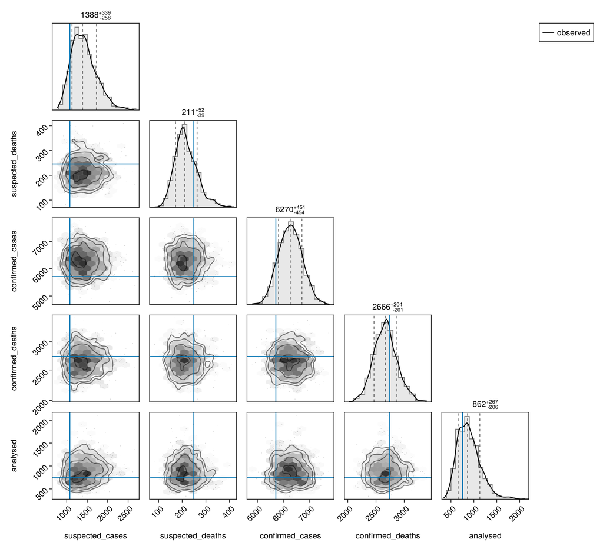

```julia
# Per-draw modelled total of each stream, summed over its own reporting
# vintages (the confirmed total adds the unscored first-vintage baseline),
# reusing the posterior-predictive replicates built for the vintage panels.
_stream_total(reps) = [sum(Float64.(collect(r))) for r in vec(reps)]
_conf_baseline = isempty(obs.confirmed_history.counts) ? 0 :
                 Int(obs.confirmed_history.counts[1])
stream_totals = (;
    suspected_cases = _stream_total(reported_panel.replicates),
    suspected_deaths = _stream_total(deaths_panel.replicates),
    confirmed_cases = _stream_total(confirmed_panel.replicates) .+ _conf_baseline,
    confirmed_deaths = _stream_total(confirmed_deaths_panel.replicates),
    analysed = _stream_total(tests_analysed_panel.replicates));
stream_observed = (;
    suspected_cases = Float64(obs.reported_history.counts[end]),
    suspected_deaths = Float64(obs.deaths_history.counts[end]),
    confirmed_cases = Float64(obs.confirmed_cases),
    confirmed_deaths = Float64(obs.confirmed_deaths_history.counts[end]),
    analysed = Float64(obs.lab_history.counts[end]));
stream_pairs_fig = plot_stream_pairs(stream_totals, stream_observed);
```

### Counterfactual: lower bound under no further transmission

**Project no-onward deaths and summarise**

julia

```julia
no_onward = predict_no_onward_deaths(
    chn_joint; obs_deaths = obs.total_deaths);

no_onward_table = streams_table(
    "no-onward total" => no_onward.total_projected;
    digits = 0);
```

1×7 DataFrame

| Row | Stream String | Lower 90% Float64 | Lower 60% Float64 | Lower 30% Float64 | Upper 30% Float64 | Upper 60% Float64 | Upper 90% Float64 |
| --- | --- | --- | --- | --- | --- | --- | --- |
| 1 | no-onward total | 246.0 | 246.0 | 246.0 | 246.0 | 246.0 | 505.0 |

**No-onward projected-deaths plot**

julia

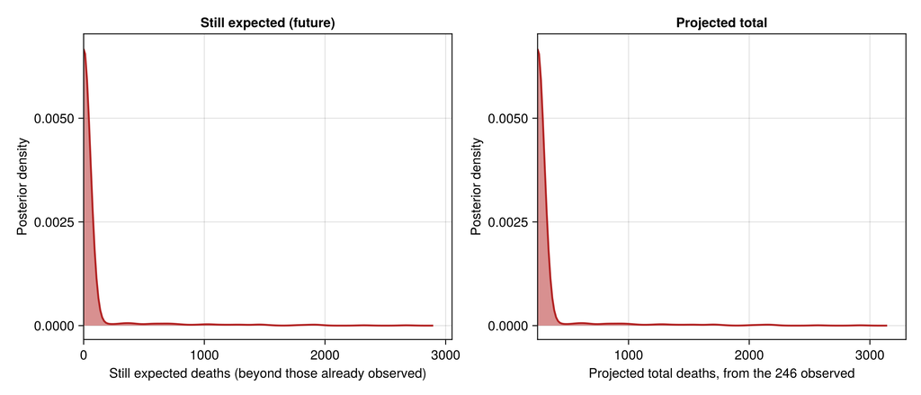

```julia
no_onward_fig = plot_no_onward_deaths(
    no_onward; obs_deaths = obs.total_deaths);
```

### Confirmed case-fatality ratio

The delay-corrected confirmed CFR, defined in the delay-corrected confirmed CFR Methods section, is set against the structural (infection-based) CFR and the naive confirmed ratio. The corrected ratio debiases the naive confirmed ratio for the real-time delay between a case being confirmed and a death being confirmed. The structural CFR is the onset-level estimate the joint model fits. Reading the three together separates the real-time delay bias (naive versus corrected) from the case/death ascertainment difference (corrected versus structural).

**Compute the confirmed-CFR comparison**

julia

```julia
confirmed_cfr = delay_corrected_confirmed_cfr(chn_joint;
    obs_confirmed = obs.confirmed_cases,
    obs_confirmed_deaths = obs.confirmed_deaths);

confirmed_cfr_summary = confirmed_cfr_table(confirmed_cfr);

# Summary line carrying the data-anchored corrected estimate alongside the
# infection-based structural CFR, so both can be quoted together.
confirmed_cfr_line = let r = confirmed_cfr
    pct(x) = round(100 * x; digits = 1)
    corr = filter(isfinite, r.corrected)
    struc = filter(isfinite, r.structural)
    cs = posterior_summary(corr)
    ss = posterior_summary(struc)
    Markdown.parse(string(
        "**Delay-corrected confirmed CFR:** ",
        pct(quantile(corr, 0.5)), "% (90% CrI ",
        pct(cs.lo90), "–", pct(cs.hi90), "%), versus a naive confirmed ratio ",
        "of ", pct(r.naive_observed), "% and a structural (infection-based) ",
        "CFR of ", pct(quantile(struc, 0.5)), "% (90% CrI ",
        pct(ss.lo90), "–", pct(ss.hi90), "%)."))
end;
```

julia

4×3 DataFrame

| Row | Quantity String | Central estimate String | Narrowest interval String |
| --- | --- | --- | --- |
| 1 | Delay-corrected confirmed CFR | 49.1% | 43.1–56.3% |
| 2 | Structural (infection-based) CFR | 47.9% | 37.7–59.2% |
| 3 | Uncorrected modelled confirmed ratio | 39.8% | 35.7–44.6% |
| 4 | Naive observed confirmed ratio | 48.0% | — |

The figure below shows the posterior densities of the delay-corrected confirmed CFR and the structural CFR. The naive observed confirmed ratio is drawn as a solid vertical rule, and the median uncorrected modelled confirmed ratio as a dashed rule. The gap from the naive rule to the corrected density is the real-time delay debiasing. The gap to the structural density is the residual case/death ascertainment difference.

**Confirmed-CFR density plot**

julia

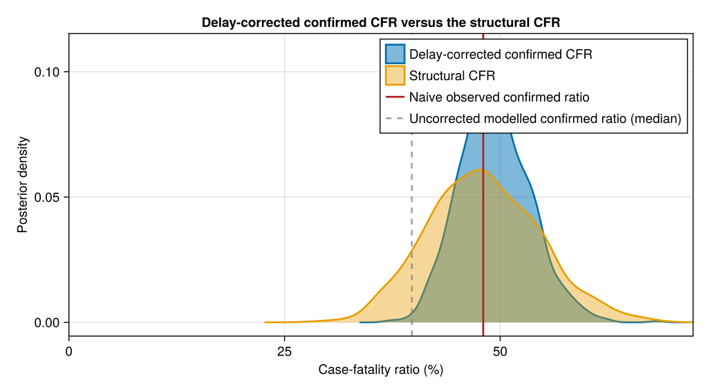

```julia
confirmed_cfr_fig = plot_confirmed_cfr(confirmed_cfr);
```

### One-week-ahead forecast results

**Generate the one-week-ahead forecast**

julia

```julia
forecast = forecast_reported(chn_joint;
    horizon = 7,
    obs_cases = obs.reported_cases,
    obs_deaths = obs.total_deaths,
    obs_confirmed = obs.confirmed_cases,
    obs_confirmed_deaths = obs.confirmed_deaths,
    obs_recovered = obs.recovered_cases);
forecast_summary = forecast_table(forecast);
```

**One-week-ahead forecast summary table**

11×8 DataFrame

| Row | Stream String | Quantity String | Lower 90% Float64 | Lower 60% Float64 | Lower 30% Float64 | Upper 30% Float64 | Upper 60% Float64 | Upper 90% Float64 |
| --- | --- | --- | --- | --- | --- | --- | --- | --- |
| 1 | DRC confirmed cases | cumulative by T+7 | 6158.0 | 6251.0 | 6305.0 | 6421.0 | 6499.0 | 6656.0 |
| 2 | DRC confirmed cases | new this week | 445.0 | 538.0 | 592.0 | 708.0 | 786.0 | 943.0 |
| 3 | DRC confirmed deaths | cumulative by T+7 | 2966.0 | 3005.0 | 3030.0 | 3074.0 | 3109.0 | 3163.0 |
| 4 | DRC confirmed deaths | new this week | 222.0 | 261.0 | 286.0 | 330.0 | 365.0 | 419.0 |
| 5 | DRC isolation beds | demand at T+7 | 653.0 | 768.0 | 835.0 | 951.0 | 1041.0 | 1201.0 |
| 6 | DRC isolation beds | occupancy at T+7 | 653.0 | 768.0 | 835.0 | 951.0 | 1041.0 | 1201.0 |
| 7 | DRC isolation admissions | daily at T+7 | 117.0 | 140.0 | 153.0 | 180.0 | 199.0 | 234.0 |
| 8 | DRC in-care deaths | daily at T+7 | 16.0 | 21.0 | 25.0 | 30.0 | 34.0 | 41.0 |
| 9 | DRC isolation rule-outs | daily at T+7 | 72.0 | 85.0 | 93.0 | 108.0 | 118.0 | 139.0 |
| 10 | DRC recovered | cumulative by T+7 | 1391.0 | 1414.0 | 1430.0 | 1460.0 | 1478.0 | 1515.0 |
| 11 | DRC recovered | new this week | 122.0 | 145.0 | 161.0 | 191.0 | 209.0 | 246.0 |

The figures below show the coming week at a glance, split into the latent quantities and the observations. The latent figure shows the new infections, symptom onsets and deaths over the horizon, with the reproduction number left to keep evolving across it.

**One-week-ahead latent forecast plot**

julia

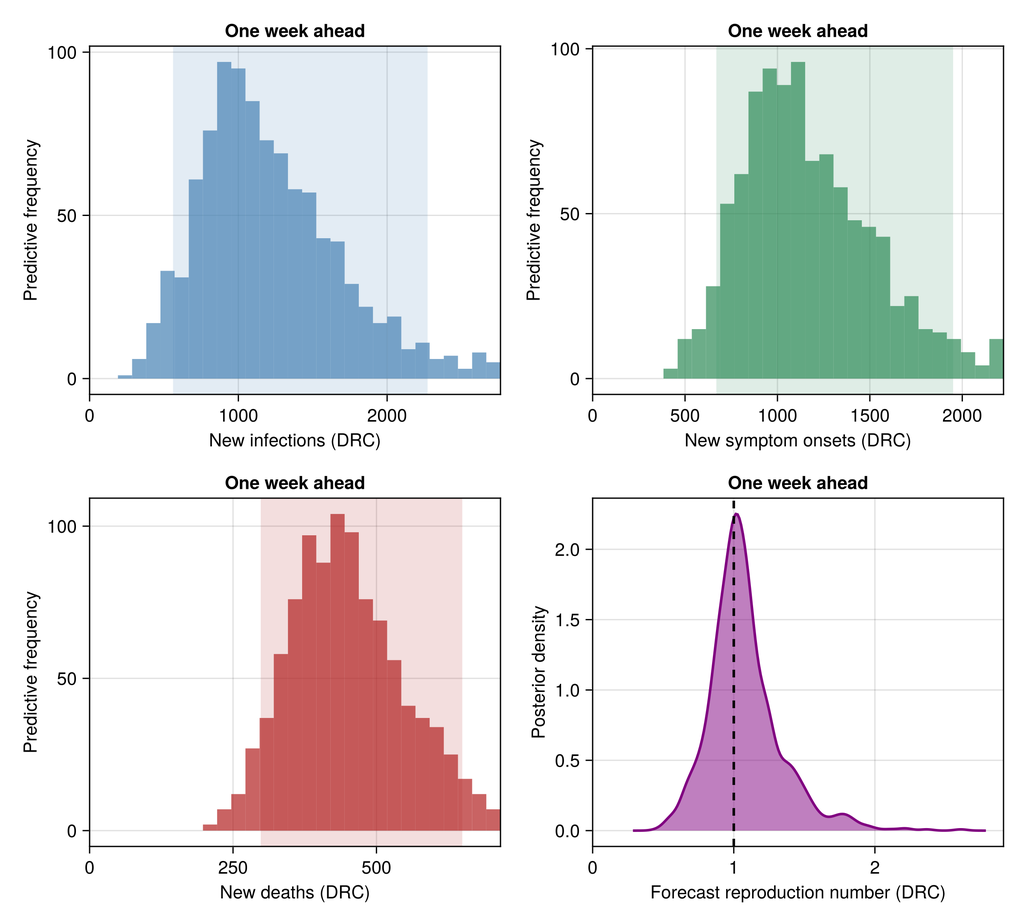

```julia
forecast_latent_fig = plot_forecast_latent(forecast);
```

The observed figure shows the new count each observed stream adds over the horizon: suspected cases, suspected deaths, laboratory-confirmed cases, confirmed deaths and recovered, one panel per stream the forecast carries.

**One-week-ahead observed forecast plot**

julia

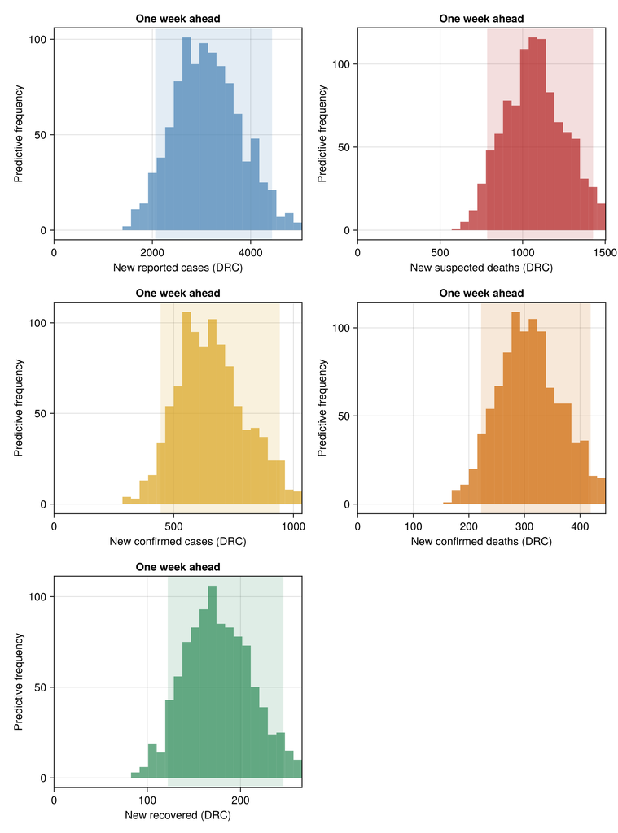

```julia
forecast_fig = plot_forecast(forecast);
```

The bed figure shows the projected isolation/treatment-bed demand (the need a week ahead, under unconstrained supply) against the supply-limited occupancy the beds can actually meet. The gap between the two is the projected bed shortfall, shown in the right panel. The reported "Patients en isolement" count is the occupied-bed count (the report computes the "Taux d'occupation" as that count over the bed capacity), so isolation is bed usage, gated by supply. The demand is its unobserved counterpart, the number who need a bed. The model carries a single national bed capacity, so it cannot represent local saturation, and the national shortfall understates local unmet need. On 13 June Ituri was at 93.9% occupancy while Sud-Kivu was at 21.9%; beds free in one province cannot serve patients in another.

**One-week-ahead isolation-bed forecast plot**

julia

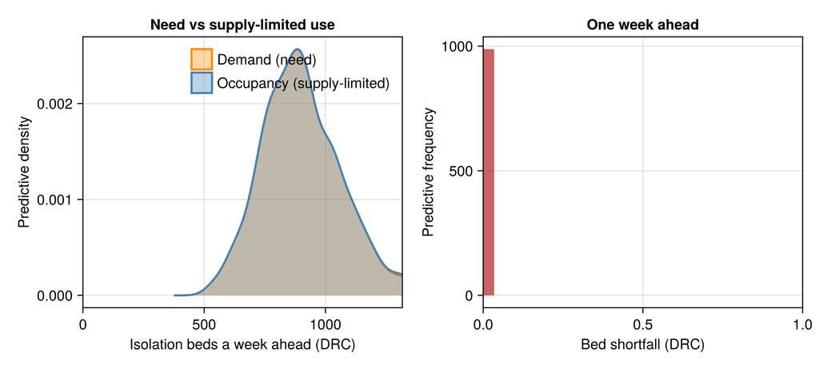

```julia
forecast_beds_fig = plot_forecast_beds(forecast);
```

The flow figure projects the daily isolation/treatment flows a week ahead: new admissions, in-care deaths and rule-outs, each grown from its cut-off daily rate and replicated through the isolation dispersion. These are the daily-flow counterparts of the bed-stock forecast above.

**One-week-ahead treatment-flow forecast plot**

julia

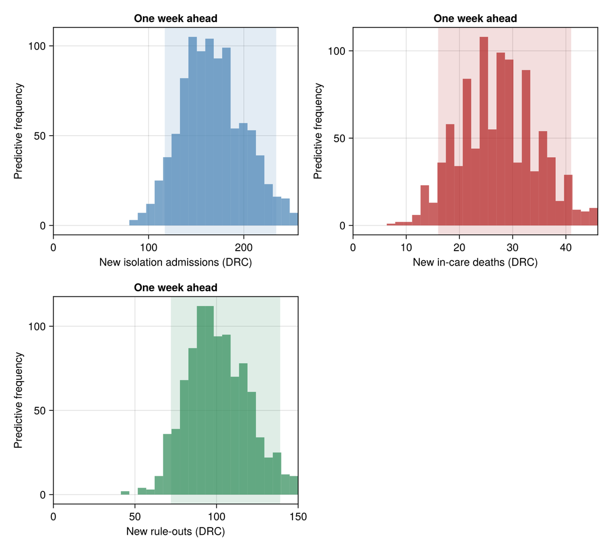

```julia
forecast_flows_fig = plot_forecast_flows(forecast);
```

### Symptom-onset nowcast and forecast results

One row deserves care. "Onsets not yet reported at T" is not a backlog that will all arrive, because ascertainment does not reach one. The row holds two things together: the reporting backlog, and the cases surveillance will never confirm. The "reports this week of onsets before T" row is the part of it the coming week should actually clear. It is the smaller number.

**Generate the symptom-onset nowcast and forecast**

julia

```julia
# The triangle's own grid, recomputed from the observations exactly as
# `onset_reporting_model` derives it, since it is data rather than chain
# contents. `_onset_grid_start`/`_onset_grid_end` are already built for the
# reporting-delay section above and reused here.
onset_forecast = forecast_onsets(chn_joint;
    grid_start = _onset_grid_start, grid_end = _onset_grid_end,
    n = obs.n, horizon = 7,
    obs_value = something(obs.onset_curve_history.last_total, 0));
onset_forecast_summary = onset_forecast_table(onset_forecast);
```

**Symptom-onset nowcast and forecast summary table**

7×7 DataFrame

| Row | Quantity String | Lower 90% Float64 | Lower 60% Float64 | Lower 30% Float64 | Upper 30% Float64 | Upper 60% Float64 | Upper 90% Float64 |
| --- | --- | --- | --- | --- | --- | --- | --- |
| 1 | symptom onsets to date | 8245.0 | 9419.0 | 10348.0 | 12376.0 | 13785.0 | 16577.0 |
| 2 | of those, reported by T | 3023.0 | 3146.0 | 3224.0 | 3351.0 | 3418.0 | 3573.0 |
| 3 | onsets not yet reported at T | 4993.0 | 6124.0 | 7094.0 | 9085.0 | 10499.0 | 13168.0 |
| 4 | reports this week of onsets before T | 146.0 | 188.0 | 211.0 | 251.0 | 282.0 | 338.0 |
| 5 | reports this week of onsets after T | 25.0 | 42.0 | 56.0 | 88.0 | 118.0 | 194.0 |
| 6 | new onset reports this week | 0.0 | 100.0 | 208.0 | 401.0 | 524.0 | 773.0 |
| 7 | new symptom onsets this week | 669.0 | 869.0 | 995.0 | 1278.0 | 1488.0 | 1951.0 |

The left panel splits the coming week's new onset reports into reports of onsets that had already happened by the cut-off and reports of onsets still to come, and shows their sum. The fourth bar is the same sum after it has been through the observation model, which is what the next vintage will actually print. It is much wider than the sum it replicates, and the gap is the rescan. At a printed total of a couple of thousand cases the per-scan level error alone is worth tens of cases either way, well above the epidemic uncertainty on a week of new reports. Only the fourth bar is comparable to a digitised figure, and only it is scored.

The right panel puts the nowcast itself on the same axes, the onsets that have happened against the share of them the triangle has printed.

**Symptom-onset nowcast and forecast plot**

julia

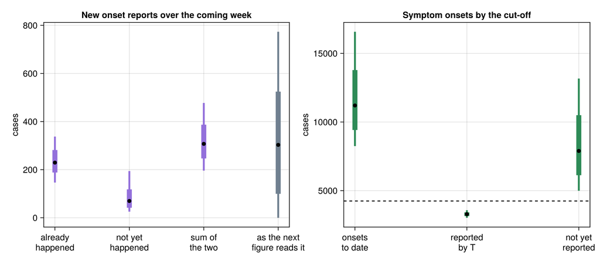

```julia
onset_forecast_fig = let
    fig = CairoMakie.Figure(; size = (960, 420))
    # Two-line tick labels rather than rotated ones: the leftmost rotated
    # label overhangs the axis and is clipped at the figure edge.
    ax1 = CairoMakie.Axis(fig[1, 1];
        title = "New onset reports over the coming week",
        ylabel = "cases", xticks = (1:4,
            ["already\nhappened", "not yet\nhappened", "sum of\nthe two",
                "as the next\nfigure reads it"]))
    # The first three bars are latent, so the third is exactly the first
    # two added. The fourth is that same sum replicated through the
    # observation model, which is the scored quantity and the only one
    # comparable to a digitised figure; it is wider by the per-scan level
    # error, which is why the three latent bars are shown as well rather
    # than a decomposition that appears not to add up.
    _latent_total = onset_forecast.onset_reports_backfill .+
                    onset_forecast.onset_reports_future
    for (i, d, col) in ((1, onset_forecast.onset_reports_backfill,
        :mediumpurple),
        (2, onset_forecast.onset_reports_future, :mediumpurple),
        (3, _latent_total, :mediumpurple),
        (4, Float64.(onset_forecast.onset_reports_new), :slategray))
        s = posterior_summary(d)
        CairoMakie.rangebars!(ax1, [Float64(i)], [s.lo90], [s.hi90];
            color = col, linewidth = 3)
        CairoMakie.rangebars!(ax1, [Float64(i)], [s.lo60], [s.hi60];
            color = col, linewidth = 8)
        CairoMakie.scatter!(ax1, [Float64(i)], [quantile(d, 0.5)];
            color = :black, markersize = 9)
    end
    ax2 = CairoMakie.Axis(fig[1, 2];
        title = "Symptom onsets by the cut-off",
        ylabel = "cases", xticks = (1:3,
            ["onsets\nto date", "reported\nby T", "not yet\nreported"]))
    for (i, d) in enumerate((onset_forecast.onsets_to_date,
        onset_forecast.onset_reports_to_date,
        onset_forecast.onsets_unreported))
        s = posterior_summary(d)
        CairoMakie.rangebars!(ax2, [Float64(i)], [s.lo90], [s.hi90];
            color = :seagreen, linewidth = 3)
        CairoMakie.rangebars!(ax2, [Float64(i)], [s.lo60], [s.hi60];
            color = :seagreen, linewidth = 8)
        CairoMakie.scatter!(ax2, [Float64(i)], [quantile(d, 0.5)];
            color = :black, markersize = 9)
    end
    # The digitised total the "reported by T" bar is a model of, so the
    # reader can see the fitted reported level against the figure itself.
    ismissing(obs.onset_curve_history.last_total) ||
        CairoMakie.hlines!(ax2,
            [Float64(obs.onset_curve_history.last_total)];
            color = :black, linestyle = :dash)
    fig
end;
```

## Saving results

The tables above are written to an output directory at the repo root so they can be archived and shared. On every push to the main branch a GitHub Actions workflow regenerates these files and publishes them as a GitHub Release, downloadable from the repository's releases page (https://github.com/epiforecasts/BVDOutbreakSize/releases). The release bundles the summary tables, a thinned set of posterior draws, the latent symptom-onset ("symptomatic cases") trajectory over time, the one- to four-week-ahead forecasts of the observed streams, and a copy of the input data manifest. Each release therefore records the forecast it made for later scoring, and the exact data that produced its results.

**Write outputs to output/**

julia

```julia
# Outputs default to `output/` in the package directory (where the
# docs build and Release workflow expect them). Set `BVD_OUTPUT_DIR`
# to redirect them, e.g. when running from a read-only package
# install.
output_dir = get(ENV, "BVD_OUTPUT_DIR",
    joinpath(pkgdir(BVDOutbreakSize), "output"))
mkpath(output_dir)

# Full parameter summary for the published CSV (infection, surveillance and
# export parameters together).
joint_summary = summary_table(chn_joint,
    [:r, :r0, :doubling_time, :T, :R_T, :CFR, :C_T,
        :p_drc, :p_uganda, :k, :tau_test, :lambda_bg,
        Symbol("exports_state.travel_state.daily_travellers")]; digits = 2)
CSV.write(joinpath(output_dir, "posterior_summary.csv"), joint_summary)
CSV.write(joinpath(output_dir, "confirmed_cfr_summary.csv"),
    confirmed_cfr_summary)

# Copy the input data so the release records what produced these
# results.
cp(joinpath(pkgdir(BVDOutbreakSize), "data", "observations.toml"),
    joinpath(output_dir, "observations.toml"); force = true)

# Thinned posterior draws of the key joint parameters (every 10th
# draw) so downstream users can recompute their own summaries.
# `cumulative_onsets_T` is the cumulative symptom onsets by the cut-off,
# the latent "symptomatic cases" outcome (the onset analogue of `C_T`),
# read off the last day of each draw's `cumulative_onsets` trajectory.
_cum_onset_draws = vec(collect(chn_joint[:cumulative_onsets]))
cumulative_onsets_T = Float64[v[end] for v in _cum_onset_draws]
# Raw walk base `log_R0`, the renewal reproduction-number walk's starting
# point on the log scale, kept unexponentiated so downstream scoring takes
# its own exp. This is a distinct quantity from `r0`, the growth-clock
# initial rate, so both columns are published side by side.
log_R0_draws = vec(Array(chn_joint[Symbol("rt_state.log_R0")]))
posterior_draws = DataFrame(
    r = vec(Array(chn_joint[:r])),
    r0 = vec(Array(chn_joint[:r0])),
    doubling_time = vec(Array(chn_joint[:doubling_time])),
    T = vec(Array(chn_joint[:T])),
    R_T = vec(Array(chn_joint[:R_T])),
    CFR = vec(Array(chn_joint[:CFR])),
    p_drc = vec(Array(chn_joint[:p_drc])),
    p_uganda = vec(Array(chn_joint[:p_uganda])),
    C_T = vec(Array(chn_joint[:C_T])),
    cumulative_onsets_T = cumulative_onsets_T,
    confirmed_cfr_corrected = confirmed_cfr.corrected
)
posterior_draws[!, Symbol("rt_state.log_R0")] = log_R0_draws
posterior_draws = posterior_draws[1:10:end, :]
CSV.write(joinpath(output_dir, "posterior_draws.csv"), posterior_draws);

# One- to four-week-ahead forecasts of the observed streams, saved as a
# release asset so each release records the forecast it made and it can later
# be scored against what is observed. Only the incident and level quantities
# are archived (see `forecast_archive`), thinned to keep the asset compact.
forecast_horizons = (7, 14, 21, 28)
forecast_runs = [(h,
                     forecast_reported(chn_joint; horizon = h,
                         obs_cases = obs.reported_cases,
                         obs_deaths = obs.total_deaths,
                         obs_confirmed = obs.confirmed_cases,
                         obs_confirmed_deaths = obs.confirmed_deaths,
                         obs_recovered = obs.recovered_cases,
                         grid_n = obs.n,
                         onset_grid_start = _onset_grid_start,
                         onset_grid_end = _onset_grid_end))
                 for h in forecast_horizons]
CSV.write(joinpath(output_dir, "forecast.csv"),
    forecast_archive(forecast_runs; made_date = obs.cutoff, thin = 5));

# The same one- to four-week-ahead forecast made from each FROZEN joint
# re-fit (the McCabe-matched cut-offs, the Chamla anchor and the one-week-back
# validation fit), each stamped with its OWN cut-off as the made date. This
# gives historical forecast evaluation using the current model at past data
# cut-offs, scored against what has since been observed, without
# reconstructing old release tags. Each frozen fit uses its own frozen
# observations for the cut-off counts. The May cut-offs predate the isolation
# and recovered streams, so those are simply absent for them; the per-stream
# guard in `forecast_archive` skips a stream a fit does not carry.
frozen_forecast_fits = unique(f -> f.o.cutoff,
    [frozen_results; frozen_by_cutoff[chamla_cutoff]; frozen_lastweek])
frozen_forecast_archive = DataFrame(made_date = Date[], horizon = Int[],
    target_date = Date[], stream = String[], draw = Int[], value = Float64[])
# The onset grid belongs to the triangle each frozen fit actually saw, not
# to the live one: the May cut-offs predate the digitised figure entirely,
# so their grid is empty and the onset block is simply absent for them.
function _frozen_onset_grid(o)
    isempty(o.onset_curve_history.onset_days) && return (nothing, nothing)
    gs = minimum(o.onset_curve_history.onset_days)
    return (gs, max(maximum(o.onset_curve_history.report_days), gs))
end
for f in frozen_forecast_fits
    _fgs, _fge = _frozen_onset_grid(f.o)
    runs = [(h,
                forecast_reported(f.chn; horizon = h,
                    obs_cases = f.o.reported_cases,
                    obs_deaths = f.o.total_deaths,
                    obs_confirmed = f.o.confirmed_cases,
                    obs_confirmed_deaths = f.o.confirmed_deaths,
                    obs_recovered = f.o.recovered_cases,
                    grid_n = f.o.n,
                    onset_grid_start = _fgs, onset_grid_end = _fge))
            for h in forecast_horizons]
    append!(frozen_forecast_archive,
        forecast_archive(runs; made_date = f.o.cutoff, thin = 5))
end
CSV.write(joinpath(output_dir, "forecast_frozen.csv"),
    frozen_forecast_archive);

# Per-fit release assets: the reproduction number, outbreak size and forecasts
# for every fit rather than the joint alone, so a release records what each
# dataset implies on its own and can later be scored against the joint. The
# single-stream fits walk Rt from day 1 while the joint walks from
# `RT_WALK_LEAD` days before the first situation report, so each fit carries
# the starts its own fit used. Each single-stream fit forecasts only the
# dataset it observes; the joint forecasts every shared stream. Recovered has
# no single-stream fit, so it stays a joint-only stream in `forecast.csv`.
stream_thin = 5
_rt_walk_start_joint = clamp(_BREAKPOINT - RT_WALK_LEAD, _rt_start_plot, obs.n)
# Observed bed occupancy at the cut-off, the level the isolation forecast
# anchors on.
_iso_at_cutoff = isempty(obs.isolation_history.counts) ? 0 :
                 obs.isolation_history.counts[end]
# The reporting triangle's own cumulative total at the cut-off. It anchors
# the reported quantity rather than changing it: the onset forecast is the
# INCREMENT this total should add over the horizon, not the level (see the
# methods section on the nowcast and forecast).
_onset_at_cutoff = something(obs.onset_curve_history.last_total, 0)
stream_fits = [
    (; fit = "joint", chn = chn_joint, rt_start = _rt_start_plot,
        rt_walk_start = _rt_walk_start_joint,
        streams = [(:reported_cases, "reported cases", obs.reported_cases),
            (:suspected_deaths, "suspected deaths", obs.total_deaths),
            (:confirmed_cases, "confirmed cases", obs.confirmed_cases),
            (:confirmed_deaths, "confirmed deaths", obs.confirmed_deaths),
            (:isolation_beds, "isolation beds", _iso_at_cutoff),
            (:exports, "exports", obs.exported_cases),
            (:onset_reports, "onset reports", _onset_at_cutoff)]),
    (; fit = "cases", chn = chn_cases, rt_start = 1, rt_walk_start = 1,
        streams = [(:reported_cases, "reported cases", obs.reported_cases)]),
    (; fit = "deaths", chn = chn_deaths, rt_start = 1, rt_walk_start = 1,
        streams = [(:suspected_deaths, "suspected deaths", obs.total_deaths)]),
    (; fit = "confirmed", chn = chn_confirmed, rt_start = 1, rt_walk_start = 1,
        streams = [(:confirmed_cases, "confirmed cases", obs.confirmed_cases)]),
    (; fit = "confirmed_deaths", chn = chn_confirmed_deaths, rt_start = 1,
        rt_walk_start = 1,
        streams = [(:confirmed_deaths, "confirmed deaths",
            obs.confirmed_deaths)]),
    (; fit = "treatment", chn = chn_treatment, rt_start = 1,
        rt_walk_start = 1,
        streams = [(:isolation_beds, "isolation beds", _iso_at_cutoff)]),
    (; fit = "exports", chn = chn_exports, rt_start = 1, rt_walk_start = 1,
        streams = [(:exports, "exports", obs.exported_cases)]),
    (; fit = "onsets", chn = chn_onsets, rt_start = 1, rt_walk_start = 1,
        streams = [(:onset_reports, "onset reports", _onset_at_cutoff)])
]
```

```julia
# Cut-off reproduction number per fit. The joint exposes it as `R_T`; the
# single-stream composers do not (the alias lives in `bvd_joint`, not the
# shared latent submodel), so theirs is rebuilt from the walk parameters every
# chain carries and read at the cut-off, the last day of the reconstructed
# path. `ramp` matches the model's 21-day intervention scale-up.
function _fit_rt_draws(f)
    f.fit == "joint" && return vec(Array(f.chn[:R_T]))
    rt = reconstruct_rt(f.chn; n = obs.n, breakpoint = _BREAKPOINT,
        rt_start = f.rt_start, rt_walk_start = f.rt_walk_start, ramp = RT_INTERVENTION_RAMP)
    return Float64[rt[i, obs.n] for i in axes(rt, 1)]
end

# Basic reproduction number per fit, the renewal walk's starting value, a
# single distribution per fit rather than a daily series. Every current
# single-stream composer shares the joint's latent submodel and so carries
# its own walk base, but `r0_walk_draws` probes rather than assumes, so a
# single-stream model built without its own renewal walk drops out of this
# quantity instead of breaking the release.
_stream_quantities = [(f.fit, _fit_rt_draws(f), vec(Array(f.chn[:C_T])),
                          r0_walk_draws(f.chn)) for f in stream_fits]

# One row per fit and quantity, with the median and the 30/60/90% credible
# bounds the report's tables use.
function _stream_estimate_row(fit, quantity, draws)
    s = posterior_summary(draws)
    return (fit = fit, quantity = quantity, median = quantile(draws, 0.5),
        lo30 = s.lo30, hi30 = s.hi30, lo60 = s.lo60, hi60 = s.hi60,
        lo90 = s.lo90, hi90 = s.hi90)
end
stream_estimates = DataFrame([_stream_estimate_row(fit, q, d)
                              for (fit, rt, ct, r0) in _stream_quantities
                              for (q, d) in (("R_T", rt), ("C_T", ct),
                                      ("R0", r0))
                              if !isnothing(d)])
CSV.write(joinpath(output_dir, "stream_estimates.csv"), stream_estimates);

# Thinned reproduction-number and outbreak-size draws per fit, so downstream
# scoring can recompute its own summaries rather than reuse the intervals.
stream_draws = DataFrame([(fit = fit, quantity = q, draw = d, value = v)
                          for (fit, rt, ct, r0) in _stream_quantities
                          for (q, vals) in (("R_T", rt), ("C_T", ct),
                                  ("R0", r0))
                          if !isnothing(vals)
                          for (d, v) in enumerate(vals[1:stream_thin:end])])
CSV.write(joinpath(output_dir, "stream_draws.csv"), stream_draws);

# Per-fit forecasts of each fit's own observed stream, in the `forecast.csv`
# long schema plus the fit that made them. Rebuilding a single-stream fit's
# cut-off growth rate needs the grid length and the breakpoint, which are data
# rather than chain contents, so both are passed.
stream_forecasts = DataFrame(made_date = Date[], horizon = Int[],
    target_date = Date[], stream = String[], draw = Int[], value = Float64[],
    fit = String[])
for f in stream_fits, (stream, label, obs_value) in f.streams,
    h in forecast_horizons
    # The onset grid is ignored by every other stream, so it is passed
    # unconditionally rather than branching the loop on the stream name.
    _vals = forecast_stream(f.chn, stream; horizon = h,
        obs_value = obs_value, n = obs.n, breakpoint = _BREAKPOINT,
        rt_start = f.rt_start, rt_walk_start = f.rt_walk_start,
        onset_grid_start = _onset_grid_start,
        onset_grid_end = _onset_grid_end)
    for (d, i) in enumerate(1:stream_thin:length(_vals))
        push!(stream_forecasts, (obs.cutoff, h, obs.cutoff + Day(h), label,
            d, Float64(_vals[i]), f.fit))
    end
end

# Confirmed/suspect ward-bed occupancy for the joint, taken from the joint's
# own `forecast_reported` runs (partitioned by the cut-off confirmed share in
# `forecast_reported`, not re-derived here) so the ward beds are scored on the
# same footing as the total occupancy in the preferred `stream_forecasts.csv`
# asset. `forecast_stream` cannot project these — the split is not a growable
# stream but a partition of the total — so they are read from the archive
# runs. Dormant until the chain carries the confirmed in-care split:
# `forecast_reported` emits these columns only when the confirmed in-care
# prevalence `expected_confirmed_incare_T` is present, so the guard skips
# them otherwise.
for (h, fc) in forecast_runs,
    (col, label) in ((:suspect_occupancy, "isolation beds (suspected)"),
        (:confirmed_occupancy, "treatment beds"))

    col in propertynames(fc) || continue
    _wvals = fc[!, col]
    for (d, i) in enumerate(1:stream_thin:length(_wvals))
        push!(stream_forecasts, (obs.cutoff, h, obs.cutoff + Day(h), label,
            d, Float64(_wvals[i]), "joint"))
    end
end
CSV.write(joinpath(output_dir, "stream_forecasts.csv"), stream_forecasts);

# Latent symptom-onset trajectory over time, the "symptomatic cases" curve,
# showing outbreak growth: one row per grid day with the 30/60/90%
# credible intervals of both the daily new and cumulative onsets.
onsets_over_time_table = onsets_over_time(chn_joint;
    n = obs.n, seeding = obs.seeding)
CSV.write(joinpath(output_dir, "onsets_over_time.csv"),
    onsets_over_time_table);
```

### Summary-page assets

**Write the dashboard assets**

julia

```julia
dashboard_dir = joinpath(
    pkgdir(BVDOutbreakSize), "docs", "src", "summary_assets")
mkpath(dashboard_dir)

# Figures: estimated R(t), the R(t) each data stream implies on its own,
# latent infections over time, and the modelled versus observed reported
# cases. All are produced in the Results sections above; here we just write
# them out at the dashboard size.
CairoMakie.save(joinpath(dashboard_dir, "rt.png"), rt_fig)
CairoMakie.save(joinpath(dashboard_dir, "infections.png"),
    cumulative_traj_fig)
# The report splits the surveillance panels by whether the stream was
# still reporting at the cut-off. The dashboard shows one grid, so it is
# drawn here over the full ordered panel set.
CairoMakie.save(joinpath(dashboard_dir, "reported_cases.png"),
    plot_vintage_conditional_ppc(vintage_panels))

# Headline prose: the same bullet summary shown at the top of the Results
# section, serialised to markdown so the dashboard renders it verbatim.
open(joinpath(dashboard_dir, "headline.md"), "w") do io
    print(io, sprint(Markdown.plain, summary_ranges))
end

# Headline tables: outbreak size and timing as whole numbers, and the
# growth and severity parameters to two decimals, each with reader-friendly
# quantity names.
dashboard_counts = summary_table(chn_joint, [:C_T, :T]; digits = 0,
    labels = Dict(:C_T => "Cumulative infections",
        :T => "Outbreak age (days)"))
dashboard_rates = summary_table(chn_joint,
    [:R0, :R_T, :r, :doubling_time, :CFR]; digits = 2,
    labels = Dict(:R0 => "Initial reproduction number",
        :R_T => "Latest reproduction number",
        :r => "Latest growth rate (per day)",
        :doubling_time => "Latest doubling time (days)",
        :CFR => "Case-fatality ratio"))
open(joinpath(dashboard_dir, "headline_counts.md"), "w") do io
    print(io, markdown_table(dashboard_counts))
end
open(joinpath(dashboard_dir, "headline_rates.md"), "w") do io
    print(io, markdown_table(dashboard_rates))
end

# The data cut-off the dashboard reports as of, written as a plain date.
open(joinpath(dashboard_dir, "cutoff.md"), "w") do io
    print(io, string(obs.cutoff))
end
```

The full analysis code, data and model definitions are in the epiforecasts/BVDOutbreakSize repository. Issues, corrections and suggestions are welcome there. Maintained by Sam Abbott, Kath Sherratt, Samuel Brand and Sebastian Funk.